# Chalder Fatigue Questionnaire - CFA

# Pytania kwestionariusza

| pytanie | zmienna | czynnik |
| --- | --- | --- |
| Czy masz problemy ze zmęczeniem? | chfq1 | phys |
| Czy potrzebujesz więcej odpoczynku? | chfq2 | phys |
| Czy czujesz się niewyspany albo senny? | chfq3 | phys |
| Czy masz problemy z rozpoczynaniem czynności? | chfq4 | phys |
| Czy brakuje Ci energii? | chfq5 | phys |
| Czy masz mniej siły w mięśniach? | chfq6 | phys |
| Czy czujesz się osłabiona / osłabiony? | chfq7 | phys |
| Czy trudno Ci się skoncentrować? | chfq8 | mental |
| Czy zdarzają Ci się przejęzyczenia? | chfq9 | mental |
| Czy jest Ci trudniej znajdować właściwe słowa? | chfq10 | mental |
| Jak się sprawuje Twoja pamięć? | chfq11 | mental |

# Rozkłady

## Poszczególne pytania

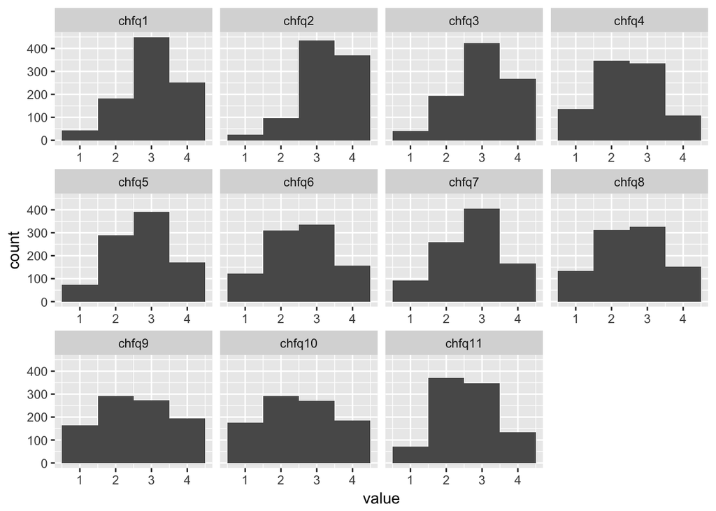

```r
# rozkłady pytań
chalder_items %>%
  melt() %>%
  ggplot() + facet_wrap(~variable, scales = 'free_x') +
  geom_histogram(aes(value), binwidth = 1)
```

`chfq2` wydaje się być bardzo skośny (ale kto nie potrzebuje więcej odpoczynku w ciąży?)

## Czynniki

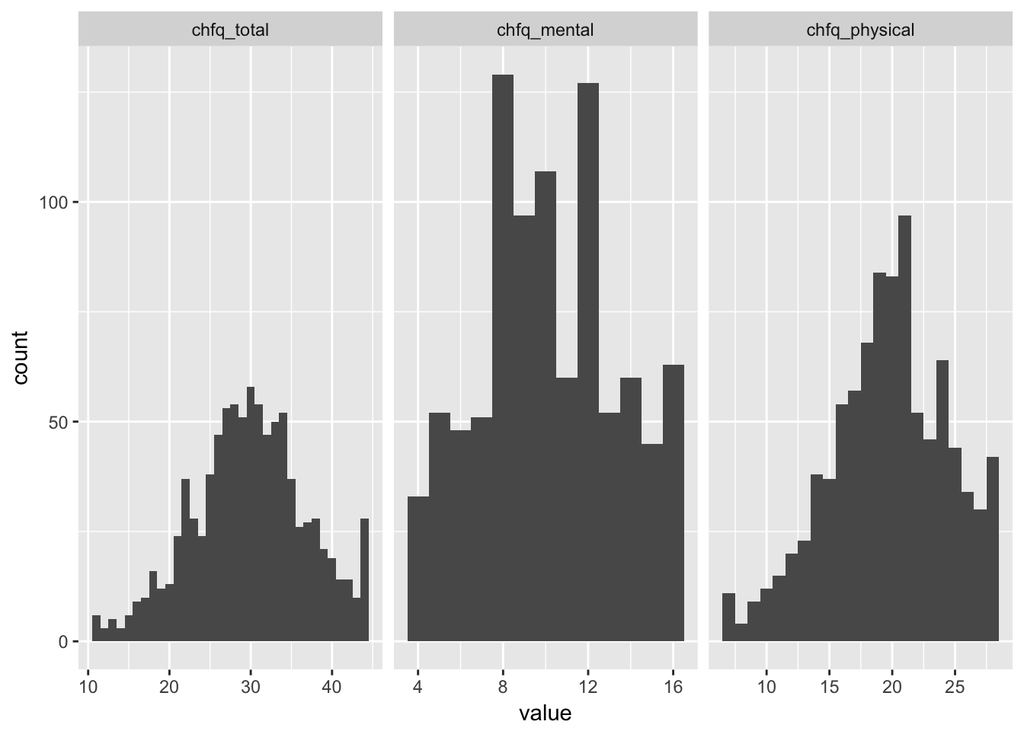

```r
# rozkłady czynników
chalder_factors %>%
  melt() %>%
  ggplot() + facet_wrap(~variable, scales = 'free_x') +
    geom_histogram(aes(value), binwidth = 1)
```

Ciekawa jest grupa osób mających maksa w skali (ponad 25). Rozkład `chfq_physical` może wskazywać na efekt sufitu - jest relatywnie dużo osób z maksem (?).

# Alfa Cronbacha

Ogólnie wskaźniki alfy Cronbacha bardzo wysokie dla całości i obu podskal, nie ma się czym przejmować.

## Dla całej skali

```r
psych::alpha(chalder_items)
```

```
##
## Reliability analysis
## Call: psych::alpha(x = chalder_items)
##
##   raw_alpha std.alpha G6(smc) average_r S/N    ase mean   sd
##       0.91      0.91    0.93      0.47 9.9 0.0047  2.7 0.64
##
##  lower alpha upper     95% confidence boundaries
## 0.9 0.91 0.92
##
##  Reliability if an item is dropped:
##        raw_alpha std.alpha G6(smc) average_r S/N alpha se
## chfq1       0.90      0.90    0.92      0.47 9.0   0.0051
## chfq2       0.90      0.90    0.92      0.47 9.0   0.0051
## chfq3       0.90      0.90    0.92      0.47 9.0   0.0051
## chfq4       0.90      0.90    0.92      0.47 8.9   0.0052
## chfq5       0.89      0.89    0.92      0.46 8.5   0.0054
## chfq6       0.90      0.90    0.92      0.47 9.0   0.0052
## chfq7       0.89      0.90    0.92      0.46 8.6   0.0053
## chfq8       0.90      0.90    0.92      0.47 8.9   0.0053
## chfq9       0.90      0.90    0.92      0.48 9.4   0.0049
## chfq10      0.90      0.90    0.92      0.48 9.3   0.0049
## chfq11      0.90      0.90    0.92      0.48 9.3   0.0051
##
##  Item statistics
##          n raw.r std.r r.cor r.drop mean   sd
## chfq1  924  0.70  0.72  0.69   0.63  3.0 0.81
## chfq2  924  0.70  0.72  0.69   0.63  3.2 0.74
## chfq3  924  0.70  0.72  0.68   0.63  3.0 0.82
## chfq4  924  0.74  0.74  0.71   0.67  2.4 0.88
## chfq5  924  0.79  0.80  0.79   0.74  2.7 0.86
## chfq6  924  0.72  0.72  0.69   0.65  2.6 0.92
## chfq7  924  0.78  0.79  0.77   0.72  2.7 0.88
## chfq8  924  0.74  0.73  0.69   0.67  2.5 0.93
## chfq9  924  0.68  0.66  0.64   0.59  2.5 1.01
## chfq10 924  0.70  0.67  0.66   0.61  2.5 1.02
## chfq11 924  0.69  0.68  0.64   0.62  2.6 0.83
##
## Non missing response frequency for each item
##           1    2    3    4 miss
## chfq1  0.05 0.20 0.48 0.27    0
## chfq2  0.03 0.10 0.47 0.40    0
## chfq3  0.04 0.21 0.46 0.29    0
## chfq4  0.15 0.37 0.36 0.12    0
## chfq5  0.08 0.31 0.42 0.18    0
## chfq6  0.13 0.33 0.36 0.17    0
## chfq7  0.10 0.28 0.44 0.18    0
## chfq8  0.15 0.34 0.35 0.16    0
## chfq9  0.18 0.32 0.29 0.21    0
## chfq10 0.19 0.32 0.29 0.20    0
## chfq11 0.08 0.40 0.38 0.15    0
```

## Dla czynnika `physical`

```r
psych::alpha(chalder_items_physical)
```

```
##
## Reliability analysis
## Call: psych::alpha(x = chalder_items_physical)
##
##   raw_alpha std.alpha G6(smc) average_r S/N    ase mean   sd
##        0.9       0.9     0.9      0.58 9.5 0.0049  2.8 0.67
##
##  lower alpha upper     95% confidence boundaries
## 0.89 0.9 0.91
##
##  Reliability if an item is dropped:
##       raw_alpha std.alpha G6(smc) average_r S/N alpha se
## chfq1      0.89      0.89    0.88      0.57 8.1   0.0056
## chfq2      0.89      0.89    0.88      0.57 8.1   0.0056
## chfq3      0.89      0.89    0.89      0.58 8.3   0.0055
## chfq4      0.90      0.90    0.89      0.59 8.8   0.0053
## chfq5      0.88      0.88    0.88      0.55 7.5   0.0062
## chfq6      0.90      0.90    0.89      0.59 8.7   0.0053
## chfq7      0.88      0.88    0.88      0.56 7.7   0.0061
##
##  Item statistics
##         n raw.r std.r r.cor r.drop mean   sd
## chfq1 924  0.80  0.80  0.77   0.72  3.0 0.81
## chfq2 924  0.79  0.80  0.77   0.72  3.2 0.74
## chfq3 924  0.78  0.78  0.73   0.69  3.0 0.82
## chfq4 924  0.76  0.75  0.69   0.66  2.4 0.88
## chfq5 924  0.86  0.85  0.83   0.80  2.7 0.86
## chfq6 924  0.77  0.75  0.70   0.66  2.6 0.92
## chfq7 924  0.84  0.84  0.81   0.77  2.7 0.88
##
## Non missing response frequency for each item
##          1    2    3    4 miss
## chfq1 0.05 0.20 0.48 0.27    0
## chfq2 0.03 0.10 0.47 0.40    0
## chfq3 0.04 0.21 0.46 0.29    0
## chfq4 0.15 0.37 0.36 0.12    0
## chfq5 0.08 0.31 0.42 0.18    0
## chfq6 0.13 0.33 0.36 0.17    0
## chfq7 0.10 0.28 0.44 0.18    0
```

## Dla czynnika `mental`

```r
psych::alpha(chalder_items_mental)
```

```
##
## Reliability analysis
## Call: psych::alpha(x = chalder_items_mental)
##
##   raw_alpha std.alpha G6(smc) average_r S/N    ase mean   sd
##       0.87      0.87    0.86      0.63 6.9 0.0067  2.5 0.81
##
##  lower alpha upper     95% confidence boundaries
## 0.86 0.87 0.89
##
##  Reliability if an item is dropped:
##        raw_alpha std.alpha G6(smc) average_r S/N alpha se
## chfq8       0.88      0.88    0.85      0.70 7.1   0.0068
## chfq9       0.81      0.81    0.75      0.59 4.4   0.0106
## chfq10      0.80      0.80    0.73      0.58 4.1   0.0112
## chfq11      0.86      0.85    0.82      0.66 5.8   0.0084
##
##  Item statistics
##          n raw.r std.r r.cor r.drop mean   sd
## chfq8  924  0.79  0.79  0.67   0.63  2.5 0.93
## chfq9  924  0.90  0.89  0.87   0.79  2.5 1.01
## chfq10 924  0.91  0.90  0.89   0.82  2.5 1.02
## chfq11 924  0.81  0.83  0.73   0.69  2.6 0.83
##
## Non missing response frequency for each item
##           1    2    3    4 miss
## chfq8  0.15 0.34 0.35 0.16    0
## chfq9  0.18 0.32 0.29 0.21    0
## chfq10 0.19 0.32 0.29 0.20    0
## chfq11 0.08 0.40 0.38 0.15    0
```

# Macierz korelacji

Policzyłem dla porządku. Tu tak na prawdę istotna jest korelacja dwóch wyodrębnionych czynników. Jest dość wysoka (.53), ale chyba mogło być gorzej. `0` w tabeli z P oznacza, że to po prostu bardzo bardzo małe P (czyli istotne).

## Macierz dla pytań

```r
cor_mat <- chalder_items %>%
  as.matrix() %>%
  rcorr()
cor_mat$r %>% as_tibble()
```

| chfq1 | chfq2 | chfq3 | chfq4 | chfq5 | chfq6 | chfq7 | chfq8 | chfq9 | chfq10 | chfq11 |
| --- | --- | --- | --- | --- | --- | --- | --- | --- | --- | --- |
| 1.0000000 | 0.7245746 | 0.6051534 | 0.4754241 | 0.5955930 | 0.4684067 | 0.6206083 | 0.3751368 | 0.2521454 | 0.2576500 | 0.3304410 |
| 0.7245746 | 1.0000000 | 0.6246486 | 0.4702182 | 0.5770398 | 0.4885346 | 0.5904226 | 0.3711598 | 0.2696719 | 0.2692952 | 0.3045253 |
| 0.6051534 | 0.6246486 | 1.0000000 | 0.5235738 | 0.6096840 | 0.4463509 | 0.5587223 | 0.4006062 | 0.2873808 | 0.2827810 | 0.3404537 |
| 0.4754241 | 0.4702182 | 0.5235738 | 1.0000000 | 0.6767454 | 0.4943000 | 0.5489976 | 0.5055834 | 0.3725554 | 0.4033694 | 0.4114185 |
| 0.5955930 | 0.5770398 | 0.6096840 | 0.6767454 | 1.0000000 | 0.6326948 | 0.6808143 | 0.4815787 | 0.3460091 | 0.3548930 | 0.4111044 |
| 0.4684067 | 0.4885346 | 0.4463509 | 0.4943000 | 0.6326948 | 1.0000000 | 0.6811438 | 0.4743504 | 0.3442658 | 0.3478341 | 0.3664944 |
| 0.6206083 | 0.5904226 | 0.5587223 | 0.5489976 | 0.6808143 | 0.6811438 | 1.0000000 | 0.4994903 | 0.3332142 | 0.3415092 | 0.3994652 |
| 0.3751368 | 0.3711598 | 0.4006062 | 0.5055834 | 0.4815787 | 0.4743504 | 0.4994903 | 1.0000000 | 0.5715533 | 0.5723237 | 0.5519266 |
| 0.2521454 | 0.2696719 | 0.2873808 | 0.3725554 | 0.3460091 | 0.3442658 | 0.3332142 | 0.5715533 | 1.0000000 | 0.8349198 | 0.6098659 |
| 0.2576500 | 0.2692952 | 0.2827810 | 0.4033694 | 0.3548930 | 0.3478341 | 0.3415092 | 0.5723237 | 0.8349198 | 1.0000000 | 0.6602515 |

[output cut: 1 more lines]

```r
cor_mat$P %>% as_tibble()
```

| chfq1 | chfq2 | chfq3 | chfq4 | chfq5 | chfq6 | chfq7 | chfq8 | chfq9 | chfq10 | chfq11 |
| --- | --- | --- | --- | --- | --- | --- | --- | --- | --- | --- |
| NA | 0 | 0 | 0 | 0 | 0 | 0 | 0 | 7.105427e-15 | 1.776357e-15 | 0 |
| 0.000000e+00 | NA | 0 | 0 | 0 | 0 | 0 | 0 | 0.000000e+00 | 0.000000e+00 | 0 |
| 0.000000e+00 | 0 | NA | 0 | 0 | 0 | 0 | 0 | 0.000000e+00 | 0.000000e+00 | 0 |
| 0.000000e+00 | 0 | 0 | NA | 0 | 0 | 0 | 0 | 0.000000e+00 | 0.000000e+00 | 0 |
| 0.000000e+00 | 0 | 0 | 0 | NA | 0 | 0 | 0 | 0.000000e+00 | 0.000000e+00 | 0 |
| 0.000000e+00 | 0 | 0 | 0 | 0 | NA | 0 | 0 | 0.000000e+00 | 0.000000e+00 | 0 |
| 0.000000e+00 | 0 | 0 | 0 | 0 | 0 | NA | 0 | 0.000000e+00 | 0.000000e+00 | 0 |
| 0.000000e+00 | 0 | 0 | 0 | 0 | 0 | 0 | NA | 0.000000e+00 | 0.000000e+00 | 0 |
| 7.105427e-15 | 0 | 0 | 0 | 0 | 0 | 0 | 0 | NA | 0.000000e+00 | 0 |
| 1.776357e-15 | 0 | 0 | 0 | 0 | 0 | 0 | 0 | 0.000000e+00 | NA | 0 |

[output cut: 1 more lines]

## Macierz dla wskaźników

```r
# macierz korelacji
cor_mat <- chalder_factors %>%
  as.matrix() %>%
  rcorr()
cor_mat$r %>% as_tibble()
```

| chfq_total | chfq_mental | chfq_physical |
| --- | --- | --- |
| 1.0000000 | 0.8214182 | 0.9198503 |
| 0.8214182 | 1.0000000 | 0.5318602 |
| 0.9198503 | 0.5318602 | 1.0000000 |

```r
cor_mat$P %>% as_tibble()
```

| chfq_total | chfq_mental | chfq_physical |
| --- | --- | --- |
| NA | 0 | 0 |
| 0 | NA | 0 |
| 0 | 0 | NA |

# CFA

To są wyniki mojej próby dokonania konfirmacyjnej analizy czynnikowej. Idąc za chińską adaptacją (która wygląda pro), stwierdziłem, że zrobię cztery modele:

1. model zakładający istnienie jednego czynnika (po prostu zmęczenie),
2. model zakładający istnienie dwóch czynników niezależnych od siebie (zmęczenie fizyczne i psychiczne)
3. model zakładający istnienie dwóch czynników (zmęczenie fizyczne i psychiczne), pomiędzy którymi jest kowariancja
4. model zakładający istnienie trzech czynników - zmęczenia fizycznego i psychicznego będących łącznie składnikami jednego dużego czynnika - zmęczenie.

Problemy:

- Nie jestem pewien czy model 2 i 3 czymkolwiek się od siebie w praktyce różnią

## Model 1 (z jednym czynnikiem)

```r
model <- "
  chfq =~ chfq1 + chfq2 + chfq3 + chfq4 + chfq5 + chfq6 + chfq7 + chfq8 + chfq9 + chfq10 + chfq11
"

cfa_1factor <- cfa(model, chalder)

summary(cfa_1factor, fit.measures = TRUE, standardized = TRUE)
```

```
## lavaan (0.5-23.1097) converged normally after  26 iterations
##
##   Number of observations                           924
##
##   Estimator                                         ML
##   Minimum Function Test Statistic             1888.717
##   Degrees of freedom                                44
##   P-value (Chi-square)                           0.000
##
## Model test baseline model:
##
##   Minimum Function Test Statistic             6420.034
##   Degrees of freedom                                55
##   P-value                                        0.000
##
## User model versus baseline model:
##
##   Comparative Fit Index (CFI)                    0.710
##   Tucker-Lewis Index (TLI)                       0.638
##
## Loglikelihood and Information Criteria:
##
##   Loglikelihood user model (H0)             -10829.704
##   Loglikelihood unrestricted model (H1)      -9885.345
##
##   Number of free parameters                         22
##   Akaike (AIC)                               21703.408
##   Bayesian (BIC)                             21809.639
##   Sample-size adjusted Bayesian (BIC)        21739.770
##
## Root Mean Square Error of Approximation:
##
##   RMSEA                                          0.213
##   90 Percent Confidence Interval          0.205  0.221
##   P-value RMSEA <= 0.05                          0.000
##
## Standardized Root Mean Square Residual:
##
##   SRMR                                           0.119
##
```

[output cut: 19 more lines]

```
##
## Variances:
##                    Estimate  Std.Err  z-value  P(>|z|)   Std.lv  Std.all
##    .chfq1             0.309    0.016   19.378    0.000    0.309    0.475
##    .chfq2             0.266    0.014   19.460    0.000    0.266    0.485
##    .chfq3             0.332    0.017   19.537    0.000    0.332    0.495
##    .chfq4             0.369    0.019   19.380    0.000    0.369    0.475
##    .chfq5             0.235    0.013   17.418    0.000    0.235    0.321
##    .chfq6             0.410    0.021   19.434    0.000    0.410    0.482
##    .chfq7             0.271    0.015   17.955    0.000    0.271    0.352
##    .chfq8             0.503    0.025   20.109    0.000    0.503    0.580
##    .chfq9             0.748    0.036   20.781    0.000    0.748    0.728
##    .chfq10            0.738    0.036   20.735    0.000    0.738    0.715
##    .chfq11            0.467    0.023   20.591    0.000    0.467    0.679
##     chfq              0.342    0.028   12.412    0.000    1.000    1.000
```

```r
residuals(cfa_1factor)
```

```
## $type
## [1] "raw"
##
## $cov
##        chfq1  chfq2  chfq3  chfq4  chfq5  chfq6  chfq7  chfq8  chfq9
## chfq1   0.000
## chfq2   0.122  0.000
## chfq3   0.060  0.069  0.000
## chfq4  -0.035 -0.032  0.006  0.000
## chfq5  -0.001 -0.009  0.017  0.060  0.000
## chfq6  -0.040 -0.019 -0.049 -0.022  0.031  0.000
## chfq7   0.026  0.008 -0.010 -0.026  0.013  0.082  0.000
## chfq8  -0.071 -0.065 -0.046  0.030 -0.042  0.007 -0.018  0.000
## chfq9  -0.103 -0.079 -0.070 -0.005 -0.073 -0.029 -0.077  0.220  0.000
## chfq10 -0.106 -0.085 -0.080  0.015 -0.074 -0.034 -0.078  0.214  0.573
## chfq11 -0.054 -0.063 -0.043  0.001 -0.040 -0.032 -0.041  0.143  0.264
##        chfq10 chfq11
## chfq1
## chfq2
## chfq3
## chfq4
## chfq5
## chfq6
## chfq7
## chfq8
## chfq9
## chfq10  0.000
## chfq11  0.301  0.000
##
## $mean
##  chfq1  chfq2  chfq3  chfq4  chfq5  chfq6  chfq7  chfq8  chfq9 chfq10
##      0      0      0      0      0      0      0      0      0      0
## chfq11
##      0
```

```r
fitmeasures(cfa_1factor)
```

```
##                npar                fmin               chisq
##              22.000               1.022            1888.717
##                  df              pvalue      baseline.chisq
##              44.000               0.000            6420.034
##         baseline.df     baseline.pvalue                 cfi
##              55.000               0.000               0.710
##                 tli                nnfi                 rfi
##               0.638               0.638               0.632
##                 nfi                pnfi                 ifi
##               0.706               0.565               0.711
##                 rni                logl   unrestricted.logl
##               0.710          -10829.704           -9885.345
##                 aic                 bic              ntotal
##           21703.408           21809.639             924.000
##                bic2               rmsea      rmsea.ci.lower
##           21739.770               0.213               0.205
##      rmsea.ci.upper        rmsea.pvalue                 rmr
##               0.221               0.000               0.106
##          rmr_nomean                srmr        srmr_bentler
##               0.106               0.119               0.119
## srmr_bentler_nomean         srmr_bollen  srmr_bollen_nomean
##               0.119               0.119               0.119
##          srmr_mplus   srmr_mplus_nomean               cn_05
##               0.119               0.119              30.589
##               cn_01                 gfi                agfi
##              34.614               0.696               0.545
##                pgfi                 mfi                ecvi
##               0.464               0.369               2.092
```

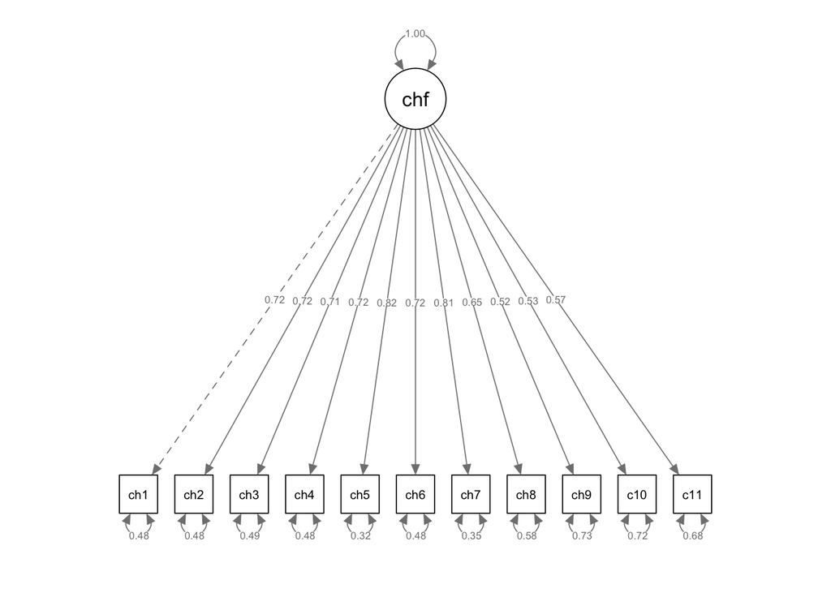

```r
semPaths(cfa_1factor, whatLabels = "std", layout = "tree")
```

## Model 2 (z dwoma czynnikami niezależnymi)

```r
model <- "
  chfq_mental =~ chfq8 + chfq9 + chfq10 + chfq11
  chfq_physical =~  chfq1 + chfq2 + chfq3 + chfq4 + chfq5 + chfq6 + chfq7
"

cfa_2factor <- cfa(model, chalder)

summary(cfa_2factor, fit.measures = TRUE, standardized = T, rsquare = T)
```

```
## lavaan (0.5-23.1097) converged normally after  31 iterations
##
##   Number of observations                           924
##
##   Estimator                                         ML
##   Minimum Function Test Statistic              646.117
##   Degrees of freedom                                43
##   P-value (Chi-square)                           0.000
##
## Model test baseline model:
##
##   Minimum Function Test Statistic             6420.034
##   Degrees of freedom                                55
##   P-value                                        0.000
##
## User model versus baseline model:
##
##   Comparative Fit Index (CFI)                    0.905
##   Tucker-Lewis Index (TLI)                       0.879
##
## Loglikelihood and Information Criteria:
##
##   Loglikelihood user model (H0)             -10208.404
##   Loglikelihood unrestricted model (H1)      -9885.345
##
##   Number of free parameters                         23
##   Akaike (AIC)                               20462.808
##   Bayesian (BIC)                             20573.868
##   Sample-size adjusted Bayesian (BIC)        20500.823
##
## Root Mean Square Error of Approximation:
##
##   RMSEA                                          0.123
##   90 Percent Confidence Interval          0.115  0.132
##   P-value RMSEA <= 0.05                          0.000
##
## Standardized Root Mean Square Residual:
##
##   SRMR                                           0.084
##
```

[output cut: 40 more lines]

```
##     chfq_physical     0.375    0.028   13.201    0.000    1.000    1.000
##
## R-Square:
##                    Estimate
##     chfq8             0.434
##     chfq9             0.795
##     chfq10            0.843
##     chfq11            0.520
##     chfq1             0.575
##     chfq2             0.564
##     chfq3             0.535
##     chfq4             0.502
##     chfq5             0.701
##     chfq6             0.513
##     chfq7             0.666
```

```r
residuals(cfa_2factor)
```

```
## $type
## [1] "raw"
##
## $cov
##        chfq8  chfq9  chfq10 chfq11 chfq1  chfq2  chfq3  chfq4  chfq5
## chfq8   0.000
## chfq9  -0.015  0.000
## chfq10 -0.031  0.017  0.000
## chfq11  0.059 -0.028 -0.002  0.000
## chfq1   0.091 -0.075 -0.079  0.035  0.000
## chfq2   0.082 -0.053 -0.061  0.018  0.092  0.000
## chfq3   0.119 -0.036 -0.049  0.049  0.033  0.046  0.000
## chfq4   0.220  0.046  0.065  0.111 -0.044 -0.040  0.004  0.000
## chfq5   0.161 -0.029 -0.031  0.074 -0.027 -0.033 -0.002  0.063  0.000
## chfq6   0.201  0.018  0.013  0.080 -0.056 -0.034 -0.059 -0.011  0.026
## chfq7   0.185 -0.032 -0.035  0.073  0.001 -0.015 -0.027 -0.022 -0.002
##        chfq6  chfq7
## chfq8
## chfq9
## chfq10
## chfq11
## chfq1
## chfq2
## chfq3
## chfq4
## chfq5
## chfq6   0.000
## chfq7   0.078  0.000
##
## $mean
##  chfq8  chfq9 chfq10 chfq11  chfq1  chfq2  chfq3  chfq4  chfq5  chfq6
##      0      0      0      0      0      0      0      0      0      0
##  chfq7
##      0
```

```r
fitmeasures(cfa_2factor)
```

```
##                npar                fmin               chisq
##              23.000               0.350             646.117
##                  df              pvalue      baseline.chisq
##              43.000               0.000            6420.034
##         baseline.df     baseline.pvalue                 cfi
##              55.000               0.000               0.905
##                 tli                nnfi                 rfi
##               0.879               0.879               0.871
##                 nfi                pnfi                 ifi
##               0.899               0.703               0.905
##                 rni                logl   unrestricted.logl
##               0.905          -10208.404           -9885.345
##                 aic                 bic              ntotal
##           20462.808           20573.868             924.000
##                bic2               rmsea      rmsea.ci.lower
##           20500.823               0.123               0.115
##      rmsea.ci.upper        rmsea.pvalue                 rmr
##               0.132               0.000               0.066
##          rmr_nomean                srmr        srmr_bentler
##               0.066               0.084               0.084
## srmr_bentler_nomean         srmr_bollen  srmr_bollen_nomean
##               0.084               0.084               0.084
##          srmr_mplus   srmr_mplus_nomean               cn_05
##               0.084               0.084              85.809
##               cn_01                 gfi                agfi
##              97.472               0.879               0.814
##                pgfi                 mfi                ecvi
##               0.573               0.722               0.749
```

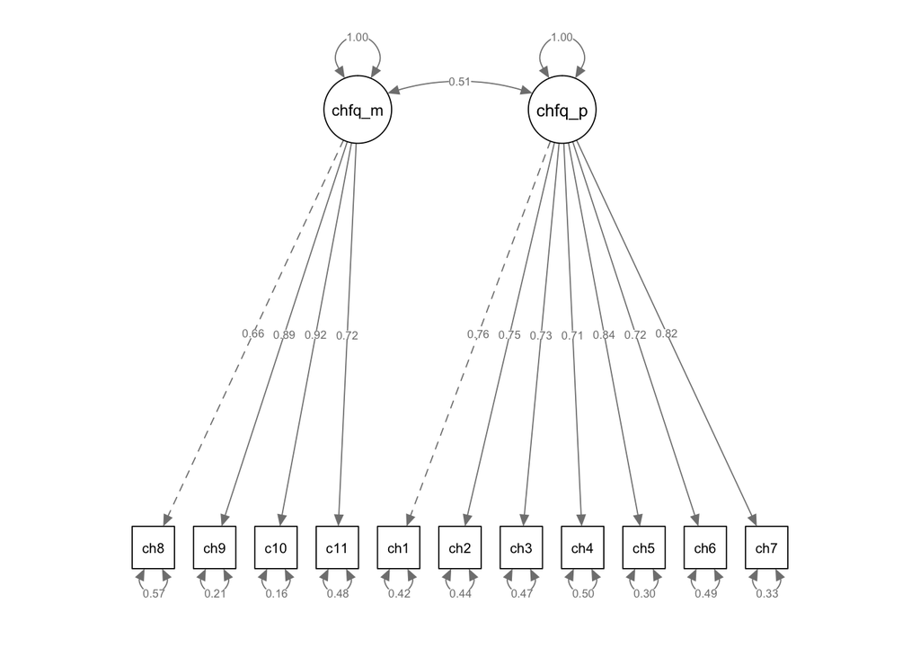

```r
semPaths(cfa_2factor, whatLabels = "std", layout = "tree")
```

## Model 3 (z dwoma czynnikami i kowariancją)

```r
model <- "
  chfq_mental =~ chfq8 + chfq9 + chfq10 + chfq11
  chfq_physical =~  chfq1 + chfq2 + chfq3 + chfq4 + chfq5 + chfq6 + chfq7
  chfq_mental ~~ chfq_physical
"

cfa_2factor_covar <- cfa(model, chalder)

summary(cfa_2factor_covar, fit.measures = TRUE, standardized = T, rsquare = T)
```

```
## lavaan (0.5-23.1097) converged normally after  31 iterations
##
##   Number of observations                           924
##
##   Estimator                                         ML
##   Minimum Function Test Statistic              646.117
##   Degrees of freedom                                43
##   P-value (Chi-square)                           0.000
##
## Model test baseline model:
##
##   Minimum Function Test Statistic             6420.034
##   Degrees of freedom                                55
##   P-value                                        0.000
##
## User model versus baseline model:
##
##   Comparative Fit Index (CFI)                    0.905
##   Tucker-Lewis Index (TLI)                       0.879
##
## Loglikelihood and Information Criteria:
##
##   Loglikelihood user model (H0)             -10208.404
##   Loglikelihood unrestricted model (H1)      -9885.345
##
##   Number of free parameters                         23
##   Akaike (AIC)                               20462.808
##   Bayesian (BIC)                             20573.868
##   Sample-size adjusted Bayesian (BIC)        20500.823
##
## Root Mean Square Error of Approximation:
##
##   RMSEA                                          0.123
##   90 Percent Confidence Interval          0.115  0.132
##   P-value RMSEA <= 0.05                          0.000
##
## Standardized Root Mean Square Residual:
##
##   SRMR                                           0.084
##
```

[output cut: 40 more lines]

```
##     chfq_physical     0.375    0.028   13.201    0.000    1.000    1.000
##
## R-Square:
##                    Estimate
##     chfq8             0.434
##     chfq9             0.795
##     chfq10            0.843
##     chfq11            0.520
##     chfq1             0.575
##     chfq2             0.564
##     chfq3             0.535
##     chfq4             0.502
##     chfq5             0.701
##     chfq6             0.513
##     chfq7             0.666
```

```r
residuals(cfa_2factor_covar)
```

```
## $type
## [1] "raw"
##
## $cov
##        chfq8  chfq9  chfq10 chfq11 chfq1  chfq2  chfq3  chfq4  chfq5
## chfq8   0.000
## chfq9  -0.015  0.000
## chfq10 -0.031  0.017  0.000
## chfq11  0.059 -0.028 -0.002  0.000
## chfq1   0.091 -0.075 -0.079  0.035  0.000
## chfq2   0.082 -0.053 -0.061  0.018  0.092  0.000
## chfq3   0.119 -0.036 -0.049  0.049  0.033  0.046  0.000
## chfq4   0.220  0.046  0.065  0.111 -0.044 -0.040  0.004  0.000
## chfq5   0.161 -0.029 -0.031  0.074 -0.027 -0.033 -0.002  0.063  0.000
## chfq6   0.201  0.018  0.013  0.080 -0.056 -0.034 -0.059 -0.011  0.026
## chfq7   0.185 -0.032 -0.035  0.073  0.001 -0.015 -0.027 -0.022 -0.002
##        chfq6  chfq7
## chfq8
## chfq9
## chfq10
## chfq11
## chfq1
## chfq2
## chfq3
## chfq4
## chfq5
## chfq6   0.000
## chfq7   0.078  0.000
##
## $mean
##  chfq8  chfq9 chfq10 chfq11  chfq1  chfq2  chfq3  chfq4  chfq5  chfq6
##      0      0      0      0      0      0      0      0      0      0
##  chfq7
##      0
```

```r
fitmeasures(cfa_2factor_covar)
```

```
##                npar                fmin               chisq
##              23.000               0.350             646.117
##                  df              pvalue      baseline.chisq
##              43.000               0.000            6420.034
##         baseline.df     baseline.pvalue                 cfi
##              55.000               0.000               0.905
##                 tli                nnfi                 rfi
##               0.879               0.879               0.871
##                 nfi                pnfi                 ifi
##               0.899               0.703               0.905
##                 rni                logl   unrestricted.logl
##               0.905          -10208.404           -9885.345
##                 aic                 bic              ntotal
##           20462.808           20573.868             924.000
##                bic2               rmsea      rmsea.ci.lower
##           20500.823               0.123               0.115
##      rmsea.ci.upper        rmsea.pvalue                 rmr
##               0.132               0.000               0.066
##          rmr_nomean                srmr        srmr_bentler
##               0.066               0.084               0.084
## srmr_bentler_nomean         srmr_bollen  srmr_bollen_nomean
##               0.084               0.084               0.084
##          srmr_mplus   srmr_mplus_nomean               cn_05
##               0.084               0.084              85.809
##               cn_01                 gfi                agfi
##              97.472               0.879               0.814
##                pgfi                 mfi                ecvi
##               0.573               0.722               0.749
```

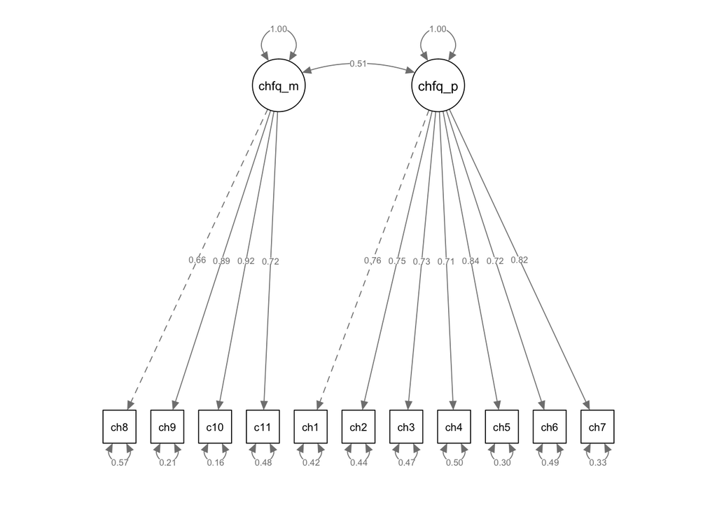

```r
semPaths(cfa_2factor_covar, whatLabels = "std", layout = "tree")
```

## Model 4 (hierarchiczny z trzema czynnikami)

```r
model <- "
  chfq_mental =~ chfq8 + chfq9 + chfq10 + chfq11
  chfq_physical =~  chfq1 + chfq2 + chfq3 + chfq4 + chfq5 + chfq6 + chfq7
  chfq =~ chfq_mental + chfq_physical
"

cfa_3factor <- sem(model, chalder)
summary(cfa_3factor, fit.measures = TRUE)
```

```
## lavaan (0.5-23.1097) converged normally after  32 iterations
##
##   Number of observations                           924
##
##   Estimator                                         ML
##   Minimum Function Test Statistic              646.117
##   Degrees of freedom                                42
##   P-value (Chi-square)                           0.000
##
## Model test baseline model:
##
##   Minimum Function Test Statistic             6420.034
##   Degrees of freedom                                55
##   P-value                                        0.000
##
## User model versus baseline model:
##
##   Comparative Fit Index (CFI)                    0.905
##   Tucker-Lewis Index (TLI)                       0.876
##
## Loglikelihood and Information Criteria:
##
##   Loglikelihood user model (H0)             -10208.404
##   Loglikelihood unrestricted model (H1)      -9885.345
##
##   Number of free parameters                         24
##   Akaike (AIC)                               20464.808
##   Bayesian (BIC)                             20580.697
##   Sample-size adjusted Bayesian (BIC)        20504.476
##
## Root Mean Square Error of Approximation:
##
##   RMSEA                                          0.125
##   90 Percent Confidence Interval          0.116  0.133
##   P-value RMSEA <= 0.05                          0.000
##
## Standardized Root Mean Square Residual:
##
##   SRMR                                           0.084
##
```

[output cut: 25 more lines]

```
##                    Estimate  Std.Err  z-value  P(>|z|)
##    .chfq8             0.491       NA
##    .chfq9             0.211       NA
##    .chfq10            0.162       NA
##    .chfq11            0.330       NA
##    .chfq1             0.276       NA
##    .chfq2             0.239       NA
##    .chfq3             0.313       NA
##    .chfq4             0.386       NA
##    .chfq5             0.219       NA
##    .chfq6             0.414       NA
##    .chfq7             0.257       NA
##     chfq_mental      -0.594       NA
##     chfq_physical     0.337       NA
##     chfq              0.972       NA
```

```r
residuals(cfa_3factor)
```

```
## $type
## [1] "raw"
##
## $cov
##        chfq8  chfq9  chfq10 chfq11 chfq1  chfq2  chfq3  chfq4  chfq5
## chfq8   0.000
## chfq9  -0.015  0.000
## chfq10 -0.031  0.017  0.000
## chfq11  0.059 -0.028 -0.002  0.000
## chfq1   0.091 -0.075 -0.079  0.035  0.000
## chfq2   0.082 -0.053 -0.061  0.018  0.092  0.000
## chfq3   0.119 -0.036 -0.049  0.049  0.033  0.046  0.000
## chfq4   0.220  0.046  0.065  0.111 -0.044 -0.040  0.004  0.000
## chfq5   0.161 -0.029 -0.031  0.074 -0.027 -0.033 -0.002  0.063  0.000
## chfq6   0.201  0.018  0.013  0.080 -0.056 -0.034 -0.059 -0.011  0.026
## chfq7   0.185 -0.032 -0.035  0.073  0.001 -0.015 -0.027 -0.022 -0.002
##        chfq6  chfq7
## chfq8
## chfq9
## chfq10
## chfq11
## chfq1
## chfq2
## chfq3
## chfq4
## chfq5
## chfq6   0.000
## chfq7   0.078  0.000
##
## $mean
##  chfq8  chfq9 chfq10 chfq11  chfq1  chfq2  chfq3  chfq4  chfq5  chfq6
##      0      0      0      0      0      0      0      0      0      0
##  chfq7
##      0
```

```r
fitmeasures(cfa_3factor)
```

```
##                npar                fmin               chisq
##              24.000               0.350             646.117
##                  df              pvalue      baseline.chisq
##              42.000               0.000            6420.034
##         baseline.df     baseline.pvalue                 cfi
##              55.000               0.000               0.905
##                 tli                nnfi                 rfi
##               0.876               0.876               0.868
##                 nfi                pnfi                 ifi
##               0.899               0.687               0.905
##                 rni                logl   unrestricted.logl
##               0.905          -10208.404           -9885.345
##                 aic                 bic              ntotal
##           20464.808           20580.697             924.000
##                bic2               rmsea      rmsea.ci.lower
##           20504.476               0.125               0.116
##      rmsea.ci.upper        rmsea.pvalue                 rmr
##               0.133               0.000               0.066
##          rmr_nomean                srmr        srmr_bentler
##               0.066               0.084               0.084
## srmr_bentler_nomean         srmr_bollen  srmr_bollen_nomean
##               0.084               0.084               0.084
##          srmr_mplus   srmr_mplus_nomean               cn_05
##               0.084               0.084              84.122
##               cn_01                 gfi                agfi
##              95.680               0.879               0.810
##                pgfi                 mfi                ecvi
##               0.559               0.721               0.751
```

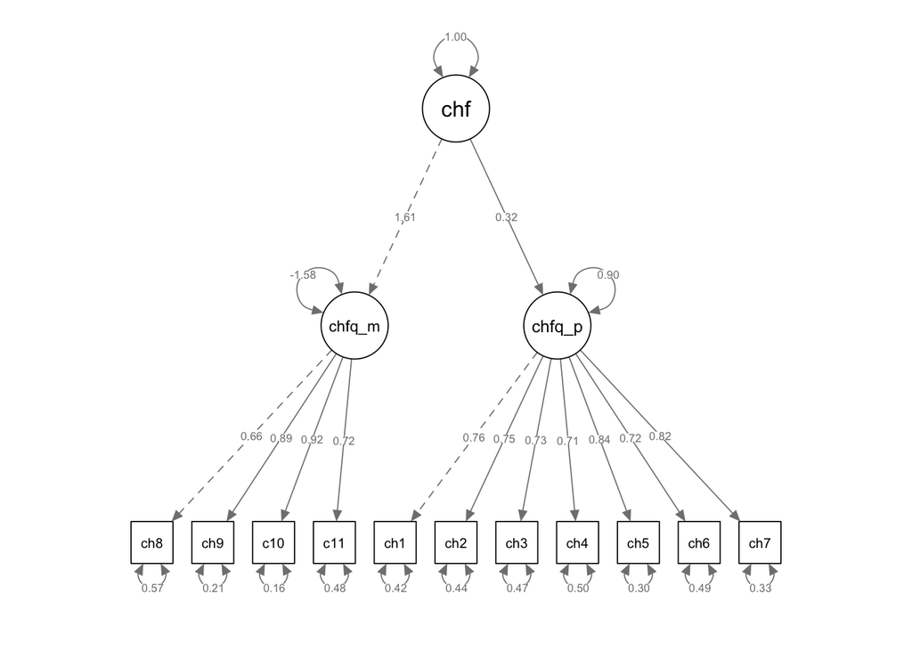

```r
semPaths(cfa_3factor, whatLabels = "std", layout = "tree")
```